# Practical Machine Learning - Prediction Assignment

Anang Hudaya Muhamad Amin

January 18, 2018

# Practical Machine Learning Project

## A. Overview

This is a final report for the peer assessment project in Coursera’s **Practical Machine Learning** course offered by Johns Hopkins University, as part of the Specialization in Data Science.

This report was developed on RStudio, using knitr tool, and meant to be published as a html page. The project consists of two different parts namely prediction assignment writeup and course quiz. The main goal of this project is to perform data analysis on the workout/exercise patterns, in identifying the quality of the respective workout being carried out. In achieving this, we going to use specific datasets of 6 participants performed specific workout actions as described in the next section. A number of machine learning algorithms will be used to train and test the accuracy of the prediction. Eventually, the algorithm which gives highest accuracy will be applied to test cases, as part of the course project prediction quiz.

## B. Project Background

Using devices such as Jawbone Up, Nike FuelBand, and Fitbit it is now possible to collect a large amount of data about personal activity relatively inexpensively. These type of devices are part of the quantified self movement - a group of enthusiasts who take measurements about themselves regularly to improve their health, to find patterns in their behavior, or because they are tech geeks. One thing that people regularly do is quantify how much of a particular activity they do, but they rarely quantify how well they do it. In this project, your goal will be to use data from accelerometers on the belt, forearm, arm, and dumbell of 6 participants. They were asked to perform barbell lifts correctly and incorrectly in 5 different ways.

More information is available from the website here: http://groupware.les.inf.puc-rio.br/har (see the section on the Weight Lifting Exercise Dataset).

## C. Exploratory Analysis

### i. Dataset Overview

The full dataset could be retrieved from: http://groupware.les.inf.puc-rio.br/har

Information about the project on collecting quantitative measurement on workout activity could be referred further in:

Velloso, E.; Bulling, A.; Gellersen, H.; Ugulino, W.; Fuks, H. **“Qualitative Activity Recognition of Weight Lifting Exercises. Proceedings of 4th International Conference in Cooperation with SIGCHI (Augmented Human ’13)”.** Stuttgart, Germany: ACM SIGCHI, 2013.

The training dataset for this project is retrieved from the following site:

https://d396qusza40orc.cloudfront.net/predmachlearn/pml-training.csv

While the test dataset could be retrieved from:

https://d396qusza40orc.cloudfront.net/predmachlearn/pml-testing.csv

The dataset is in the format of csv file, containing about 160 attributes.

Credits should be given to the above authors for their work. The following paragraph is taken from their website, which provides a short description of the dataset:

“Six young health participants were asked to perform one set of 10 repetitions of the Unilateral Dumbbell Biceps Curl in five different fashions: exactly according to the specification (Class A), throwing the elbows to the front (Class B), lifting the dumbbell only halfway (Class C), lowering the dumbbell only halfway (Class D) and throwing the hips to the front (Class E).”

From the description above, Class A is the most accurate representation of correct execution of the exercise, while the remaining classes (B,C,D, and E) indicate common mistakes.

### ii. Preparing the Environment

In order to start with the analysis process, we prepare the working environment with necessary tools and libraries:

```r
rm(list=ls())                # free up memory for the download of the data sets
library(knitr)
library(caret)
library(rpart)
library(rpart.plot)
library(rattle)
library(randomForest)
library(corrplot)
set.seed(56789)
```

### iii. Data Loading and Cleaning

The dataset used in this project can be directly downloaded from the two URLs given in the previous subsection. The training dataset is then be partitioned to create a Training set (70% of the data) for the modeling process and a Test set (with the remaining 30%) for the validations. The testing dataset will remain unchanged and will only be used for the quiz results generation.

```r
# Set the URL for download
TrainUrl <- "http://d396qusza40orc.cloudfront.net/predmachlearn/pml-training.csv"
TestUrl  <- "http://d396qusza40orc.cloudfront.net/predmachlearn/pml-testing.csv"

# download the datasets
trainData <- read.csv(url(TrainUrl))
testData  <- read.csv(url(TestUrl))

# partition the training dataset
inTrain  <- createDataPartition(trainData$classe, p=0.7, list=FALSE)
TrainingSet <- trainData[inTrain, ]
TestingSet  <- trainData[-inTrain, ]

# viewing dimension of TrainingSet data structure
dim(TrainingSet)
```

```
## [1] 13737   160
```

```r
# viewing dimension of TestingSet data structure
dim(TestingSet)
```

```
## [1] 5885  160
```

Both datasets have 160 variables. As shown from the output of the code above, there are many variables with NA, that can be removed. The following procedure is carried out to remove the Near Zero variance (NZV) variables as well as variables with most NA values.

```r
# remove variables with Nearly Zero Variance
NearZero <- nearZeroVar(TrainingSet)
TrainingSet <- TrainingSet[, -NearZero]
TestingSet  <- TestingSet[, -NearZero]

# viewing dimension of TrainingSet data structure
dim(TrainingSet)
```

```
## [1] 13737   102
```

```r
# viewing dimension of TestingSet data structure
dim(TestingSet)
```

```
## [1] 5885  102
```

```r
# remove variables that are mostly NA
MostNA    <- sapply(TrainingSet, function(x) mean(is.na(x))) > 0.95
TrainingSet <- TrainingSet[, MostNA==FALSE]
TestingSet  <- TestingSet[, MostNA==FALSE]


# viewing TrainingSet data structure
str(TrainingSet)
```

```
## 'data.frame':    13737 obs. of  59 variables:
##  $ X                   : int  3 5 6 7 10 11 12 13 14 16 ...
##  $ user_name           : Factor w/ 6 levels "adelmo","carlitos",..: 2 2 2 2 2 2 2 2 2 2 ...
##  $ raw_timestamp_part_1: int  1323084231 1323084232 1323084232 1323084232 1323084232 1323084232 1323084232 1323084232 1323084232 1323084232 ...
##  $ raw_timestamp_part_2: int  820366 196328 304277 368296 484434 500302 528316 560359 576390 644302 ...
##  $ cvtd_timestamp      : Factor w/ 20 levels "02/12/2011 13:32",..: 9 9 9 9 9 9 9 9 9 9 ...
##  $ num_window          : int  11 12 12 12 12 12 12 12 12 12 ...
##  $ roll_belt           : num  1.42 1.48 1.45 1.42 1.45 1.45 1.43 1.42 1.42 1.48 ...
##  $ pitch_belt          : num  8.07 8.07 8.06 8.09 8.17 8.18 8.18 8.2 8.21 8.15 ...
##  $ yaw_belt            : num  -94.4 -94.4 -94.4 -94.4 -94.4 -94.4 -94.4 -94.4 -94.4 -94.4 ...
##  $ total_accel_belt    : int  3 3 3 3 3 3 3 3 3 3 ...
##  $ gyros_belt_x        : num  0 0.02 0.02 0.02 0.03 0.03 0.02 0.02 0.02 0 ...
##  $ gyros_belt_y        : num  0 0.02 0 0 0 0 0 0 0 0 ...
##  $ gyros_belt_z        : num  -0.02 -0.02 -0.02 -0.02 0 -0.02 -0.02 0 -0.02 0 ...
##  $ accel_belt_x        : int  -20 -21 -21 -22 -21 -21 -22 -22 -22 -21 ...
```

[output cut: 45 more lines]

```r
# viewing TestingSet data structure
str(TestingSet)
```

```
## 'data.frame':    5885 obs. of  59 variables:
##  $ X                   : int  1 2 4 8 9 15 20 23 26 31 ...
##  $ user_name           : Factor w/ 6 levels "adelmo","carlitos",..: 2 2 2 2 2 2 2 2 2 2 ...
##  $ raw_timestamp_part_1: int  1323084231 1323084231 1323084232 1323084232 1323084232 1323084232 1323084232 1323084232 1323084233 1323084233 ...
##  $ raw_timestamp_part_2: int  788290 808298 120339 440390 484323 604281 788335 932285 56286 152353 ...
##  $ cvtd_timestamp      : Factor w/ 20 levels "02/12/2011 13:32",..: 9 9 9 9 9 9 9 9 9 9 ...
##  $ num_window          : int  11 11 12 12 12 12 12 12 13 13 ...
##  $ roll_belt           : num  1.41 1.41 1.48 1.42 1.43 1.45 1.59 1.56 1.55 1.53 ...
##  $ pitch_belt          : num  8.07 8.07 8.05 8.13 8.16 8.2 8.07 8.1 8.09 8.17 ...
##  $ yaw_belt            : num  -94.4 -94.4 -94.4 -94.4 -94.4 -94.4 -94.4 -94.3 -94.4 -94.4 ...
##  $ total_accel_belt    : int  3 3 3 3 3 3 3 3 3 3 ...
##  $ gyros_belt_x        : num  0 0.02 0.02 0.02 0.02 0 0.02 0.02 0.02 0.02 ...
##  $ gyros_belt_y        : num  0 0 0 0 0 0 0 0 0 0.02 ...
##  $ gyros_belt_z        : num  -0.02 -0.02 -0.03 -0.02 -0.02 0 -0.02 -0.02 0 -0.02 ...
##  $ accel_belt_x        : int  -21 -22 -22 -22 -20 -21 -22 -21 -21 -21 ...
```

[output cut: 45 more lines]

The dataset also contains identification only dataset (attributes 1 - 5). These columns will also be removed.

```r
# remove identification only variables (columns 1 to 5)
TrainingSet <- TrainingSet[, -(1:5)]
TestingSet  <- TestingSet[, -(1:5)]

# viewing dimension of TrainingSet data structure
dim(TrainingSet)
```

```
## [1] 13737    54
```

```r
# viewing dimension of TestingSet data structure
dim(TestingSet)
```

```
## [1] 5885   54
```

After all the cleaning procedures carried out, the dataset is reduced to 54 attributes.

### iv. Correlation Analysis

In this section, we analyzed the correlation among the attributes (variables) within the training dataset. The following correlation plot shows the respective correlation. The highly correlated variables are shown in dark colors in the graph below.

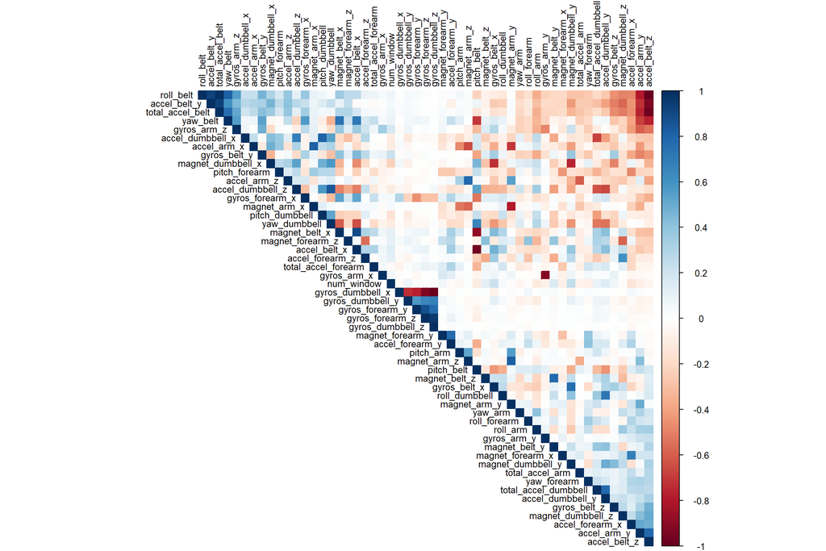

## D. Prediction Models

In this project, we will implement three machine lerning algorithms to model the regressions (in the Training dataset). The algorithm that produces highest accuracy on the test dataset will be used for the quiz predictions. The algorithms include: Decision Tree, Random Forests and Generalized Boosted Model.

To visualize the results of the prediction, Confusion Matrix will be plotted at the end of each analysis.

### i. Decision Trees

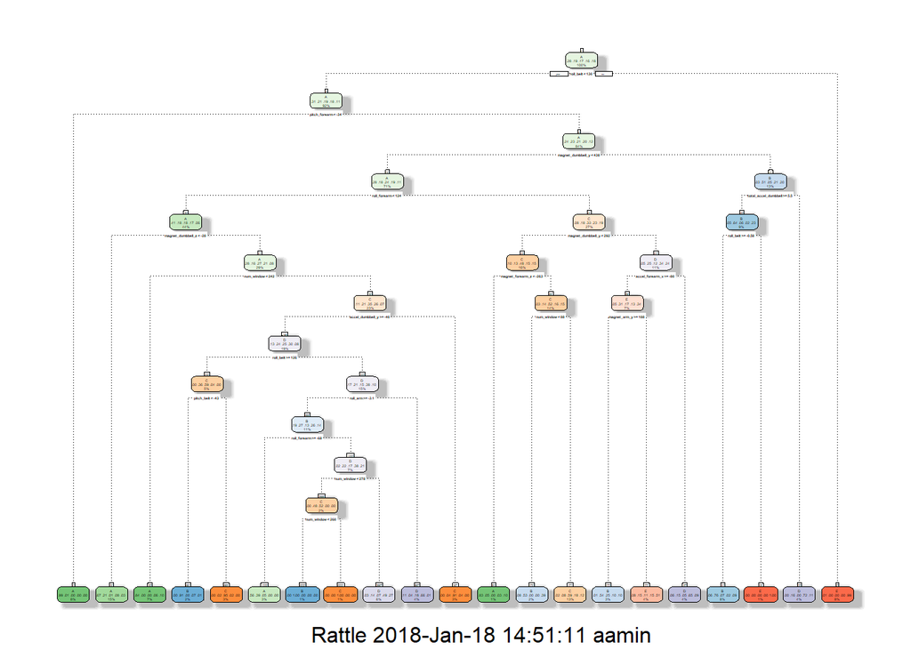

```r
# model fit - Decision Tree
set.seed(56789)
modFitDecTree <- rpart(classe ~ ., data=TrainingSet, method="class")
fancyRpartPlot(modFitDecTree)
```

```r
# prediction on Test dataset
predictDecTree <- predict(modFitDecTree, newdata=TestingSet, type="class")
confMatDecTree <- confusionMatrix(predictDecTree, TestingSet$classe)
confMatDecTree
```

```
## Confusion Matrix and Statistics
##
##           Reference
## Prediction    A    B    C    D    E
##          A 1526  264   20   93   82
##          B   41  646   56   31   85
##          C   20   74  852  133   93
##          D   61  126   72  665  128
##          E   26   29   26   42  694
##
## Overall Statistics
##
##                Accuracy : 0.7448
##                  95% CI : (0.7334, 0.7559)
##     No Information Rate : 0.2845
##     P-Value [Acc > NIR] : < 2.2e-16
##
##                   Kappa : 0.6754
##  Mcnemar's Test P-Value : < 2.2e-16
##
## Statistics by Class:
##
##                      Class: A Class: B Class: C Class: D Class: E
## Sensitivity            0.9116   0.5672   0.8304   0.6898   0.6414
## Specificity            0.8910   0.9551   0.9341   0.9214   0.9744
## Pos Pred Value         0.7688   0.7520   0.7270   0.6321   0.8494
## Neg Pred Value         0.9621   0.9019   0.9631   0.9381   0.9234
## Prevalence             0.2845   0.1935   0.1743   0.1638   0.1839
## Detection Rate         0.2593   0.1098   0.1448   0.1130   0.1179
## Detection Prevalence   0.3373   0.1460   0.1992   0.1788   0.1388
## Balanced Accuracy      0.9013   0.7611   0.8823   0.8056   0.8079
```

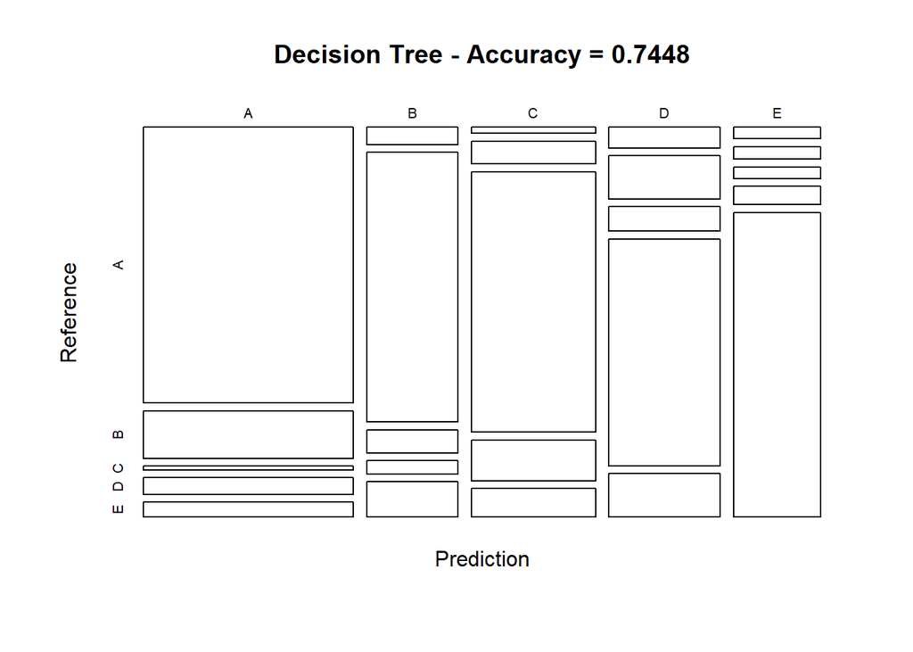

```r
# plot matrix results
plot(confMatDecTree$table, col = confMatDecTree$byClass, main = paste("Decision Tree - Accuracy =", round(confMatDecTree$overall['Accuracy'], 4)))
```

### ii. Random Forest

```r
# model fit Random Forest
set.seed(56789)
controlRF <- trainControl(method="cv", number=3, verboseIter=FALSE)
modFitRandForest <- train(classe ~ ., data=TrainingSet, method="rf", trControl=controlRF)
modFitRandForest$finalModel
```

```
##
## Call:
##  randomForest(x = x, y = y, mtry = param$mtry)
##                Type of random forest: classification
##                      Number of trees: 500
## No. of variables tried at each split: 27
##
##         OOB estimate of  error rate: 0.17%
## Confusion matrix:
##      A    B    C    D    E  class.error
## A 3904    1    0    0    1 0.0005120328
## B    3 2652    2    1    0 0.0022573363
## C    0    7 2389    0    0 0.0029215359
## D    0    0    5 2247    0 0.0022202487
## E    0    0    0    4 2521 0.0015841584
```

```r
# prediction on Test dataset
predictRandForest <- predict(modFitRandForest, newdata=TestingSet)
confMatRandForest <- confusionMatrix(predictRandForest, TestingSet$classe)
confMatRandForest
```

```
## Confusion Matrix and Statistics
##
##           Reference
## Prediction    A    B    C    D    E
##          A 1674    3    0    0    0
##          B    0 1136    1    0    0
##          C    0    0 1022    4    0
##          D    0    0    3  960    1
##          E    0    0    0    0 1081
##
## Overall Statistics
##
##                Accuracy : 0.998
##                  95% CI : (0.9964, 0.9989)
##     No Information Rate : 0.2845
##     P-Value [Acc > NIR] : < 2.2e-16
##
##                   Kappa : 0.9974
##  Mcnemar's Test P-Value : NA
##
## Statistics by Class:
##
##                      Class: A Class: B Class: C Class: D Class: E
## Sensitivity            1.0000   0.9974   0.9961   0.9959   0.9991
## Specificity            0.9993   0.9998   0.9992   0.9992   1.0000
## Pos Pred Value         0.9982   0.9991   0.9961   0.9959   1.0000
## Neg Pred Value         1.0000   0.9994   0.9992   0.9992   0.9998
## Prevalence             0.2845   0.1935   0.1743   0.1638   0.1839
## Detection Rate         0.2845   0.1930   0.1737   0.1631   0.1837
## Detection Prevalence   0.2850   0.1932   0.1743   0.1638   0.1837
## Balanced Accuracy      0.9996   0.9986   0.9976   0.9975   0.9995
```

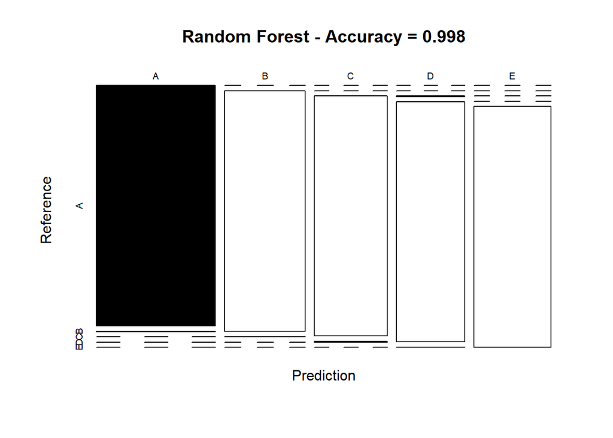

```r
# plot matrix results
plot(confMatRandForest$table, col = confMatRandForest$byClass, main = paste("Random Forest - Accuracy =", round(confMatRandForest$overall['Accuracy'], 4)))
```

### iii. Generalized Boosted Model

```r
# model fit - GBM
set.seed(56789)
controlGBM <- trainControl(method = "repeatedcv", number = 5, repeats = 1)
modFitGBM  <- train(classe ~ ., data=TrainingSet, method = "gbm", trControl = controlGBM, verbose = FALSE)
modFitGBM$finalModel
```

```
## A gradient boosted model with multinomial loss function.
## 150 iterations were performed.
## There were 53 predictors of which 42 had non-zero influence.
```

```r
# prediction on Test dataset
predictGBM <- predict(modFitGBM, newdata=TestingSet)
confMatGBM <- confusionMatrix(predictGBM, TestingSet$classe)
confMatGBM
```

```
## Confusion Matrix and Statistics
##
##           Reference
## Prediction    A    B    C    D    E
##          A 1668    9    0    0    0
##          B    5 1120    3    3    2
##          C    0    9 1021    6    1
##          D    1    1    2  953   12
##          E    0    0    0    2 1067
##
## Overall Statistics
##
##                Accuracy : 0.9905
##                  95% CI : (0.9877, 0.9928)
##     No Information Rate : 0.2845
##     P-Value [Acc > NIR] : < 2.2e-16
##
##                   Kappa : 0.988
##  Mcnemar's Test P-Value : NA
##
## Statistics by Class:
##
##                      Class: A Class: B Class: C Class: D Class: E
## Sensitivity            0.9964   0.9833   0.9951   0.9886   0.9861
## Specificity            0.9979   0.9973   0.9967   0.9967   0.9996
## Pos Pred Value         0.9946   0.9885   0.9846   0.9835   0.9981
## Neg Pred Value         0.9986   0.9960   0.9990   0.9978   0.9969
## Prevalence             0.2845   0.1935   0.1743   0.1638   0.1839
## Detection Rate         0.2834   0.1903   0.1735   0.1619   0.1813
## Detection Prevalence   0.2850   0.1925   0.1762   0.1647   0.1816
## Balanced Accuracy      0.9971   0.9903   0.9959   0.9927   0.9929
```

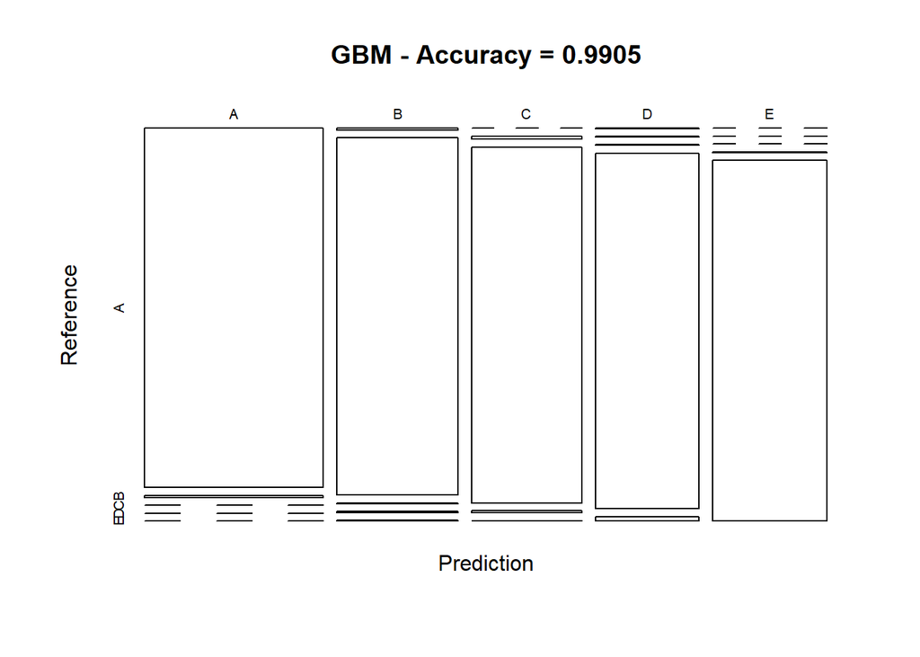

```r
# plot matrix results
plot(confMatGBM$table, col = confMatGBM$byClass, main = paste("GBM - Accuracy =", round(confMatGBM$overall['Accuracy'], 4)))
```

## E. Selected Model

Based on the analysis on different algorithms being used for the prediction model, we derived with the following results on identification accuracy:

Decision Trees: 0.7448  
Random Forest: 0.998  
Generalized Boosted Model: 0.9905

In that case, the Random Forest model will be applied to predict the 20 quiz results (testing dataset) as shown below.

```r
predictTEST <- predict(modFitRandForest, newdata=testData)
predictTEST
```

```
##  [1] B A B A A E D B A A B C B A E E A B B B
## Levels: A B C D E
```